# Does it work? Performance on the exam

Florian Sense

July 2018 – last compiled: 2018-11-06 17:37:48

# Goal

We want to get a global overview of whether (1) studying with the system improves performance on (a) the exam as a whole and (b) individual exam questions that were studied or not. Additionally, we’d like to know whether (2) usage statistics and model estimates can predict performance (for both (a) and (b) again).

```r
library(BayesFactor)
```

```r
library(ggplot2)
theme_set(theme_minimal())

# For regression models:
library(lme4)

load(file.path("..", "data", "cogpsych_data_anon.Rdata"))
figures.folder <- "figures for ICCM poster"
```

# Does studying with the system improve exam performance?

## Final grade on the exam

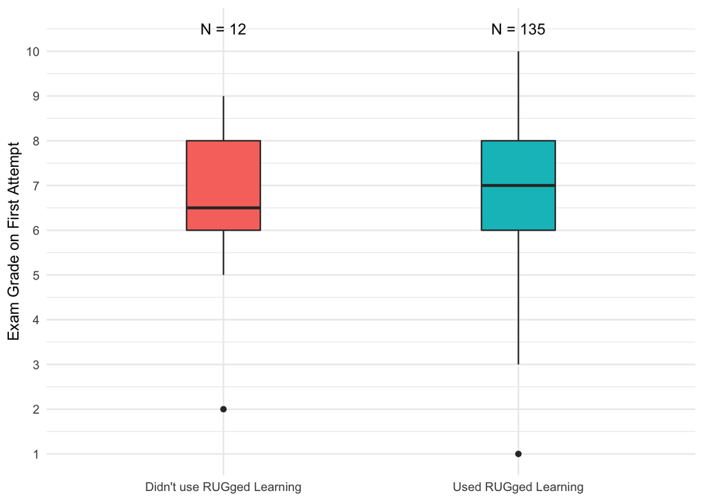

```r
grades$usedRL <- ifelse(grades$User %in% data$User, "Used RUGged Learning", "Didn't use RUGged Learning")

bf.alt <- round( as.vector(ttestBF(formula=Grade ~ usedRL, data=grades)) , 2)

grand.means <- aggregate(Grade ~ usedRL, grades, mean) # Globally
Ns <- data.frame(N = table(grades$usedRL), median = aggregate(Grade ~ usedRL, grades, median)$Grade)

ggplot(grades, aes(x=usedRL, y=Grade)) +
  # geom_violin(scale="count", draw_quantiles = c(.25, .5, .75)) +
  geom_boxplot(width=.25, aes(fill=usedRL), show.legend = FALSE) +
  annotate("text", x=1:2, y=10.5, label=paste("N =", Ns$N.Freq)) + scale_y_continuous(breaks=1:10) +
  labs(x=NULL, y="Exam Grade on First Attempt") +
  NULL
```

Note that these distributions are quite imbalanced: Only 12 of the students that gave informed consent did not use the system at all (8.2%). The mean grade for those students is 6.5 compared with a mean grade of 7.07 for the 135 students that did use the system. Given the small sample size for one of the groups, this overall difference should be interpreted with caution, though.

## Individual items on the exam

To gain a bit more insight, we can zoom in on the individual exam questions. The vast majority of the students did you use the system, which makes the comparison above extremely imbalanced. Even the people that did use RL, however, did not (necessarily) see *all* the items. This allows us to split, even within a person, the performance on the exam between those that did see the items and those that did not. So what I’ll do is compute the proportion correct on the exam separately for each student: one for the items that they did study (if any) and one for the items they did not study.

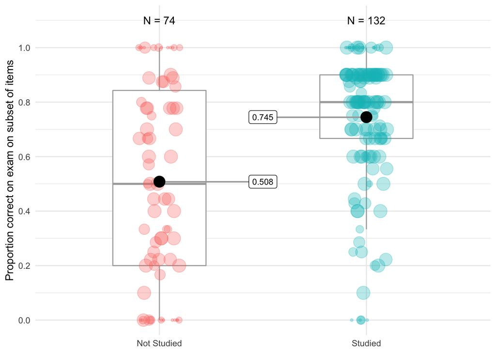

```r
grand.means <- aggregate(correct.exam ~ studied, exam.item, mean) # Globally

exam.per.student <- aggregate(correct.exam ~ Username + studied, exam.item, mean)
exam.per.student$count <- aggregate(correct.exam ~ Username + studied, exam.item, length)$correct.exam

Ns <- data.frame(N = table(exam.per.student$studied), Y = rep(1.1, 2))

pj <- position_jitter(width=.1, height = 0)

ggplot(exam.per.student, aes(studied, correct.exam)) +
  # geom_violin(scale="count") +
  geom_boxplot(width=.45, outlier.color = NA, color="darkgray") +
  # geom_line(aes(group=Username), color="lightgrey", alpha=.5, position=pj) +
  geom_point(aes(color=studied, size=count), alpha=.3, position=pj, show.legend = FALSE) +
  geom_segment(aes(x = 1, y = grand.means$correct.exam[1], xend = 1.5, yend = grand.means$correct.exam[1]), color="darkgrey") +
  geom_segment(aes(x = 1.5, y = grand.means$correct.exam[2], xend = 2, yend = grand.means$correct.exam[2]), color="darkgrey") +
  geom_point(data=grand.means, size=5) +
  annotate("text", x=1:2, y=Ns$Y, label=paste("N =", Ns$N.Freq)) +
  scale_y_continuous(breaks=seq(0, 1, .2)) +
  annotate("label", x=c(1.5, 1.5), y=grand.means$correct.exam, label=format(round(grand.means$correct.exam, 3), nsmall=3), size=3) +
  labs(x=NULL, y="Proportion correct on exam on subset of items", size=NULL) +
  # scale_colour_discrete(guide = FALSE) +
  NULL
```

```r
# ggsave(file.path(figures.folder, "Proportion correct on exam f(studied).pdf"), width = 3, height = 5)
```

The size of the points indicates the number of observations the proportion is based on, smaller points correspond to fewer observations.

What we see here is that of the 135 students that used RL to study, only 132 studied at least one item that appeared on the exam. Conversely, while there only 12 students that didnt’t use RL at all, there are 74 students that didn’t see a single item that appeared on the exam (either because they didn’t use RL or because they just didn’t encounter any of those items).

The main conclusion here is thae the proportion is much higher for the items that were studied.

One quick check we might want to do is plot the same but only for proportions that are based on at least `x` values:

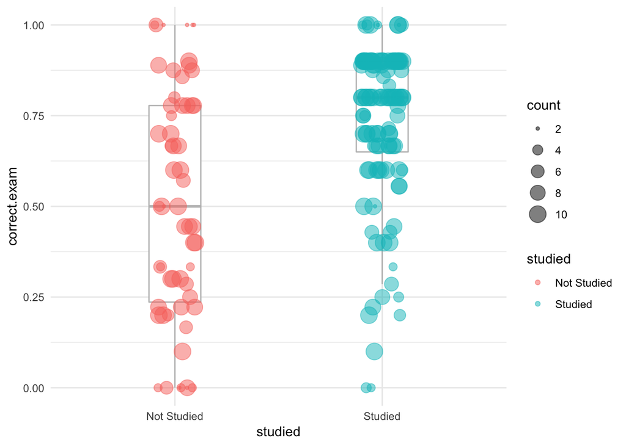

```r
x <- 2
ggplot(subset(exam.per.student, count >= x), aes(studied, correct.exam)) +
  geom_boxplot(width=.25, outlier.color = NA, color="gray") +
  geom_point(aes(color=studied, size=count), alpha=.5, position=position_jitter(width=.1, height = 0)) +
  NULL
```

Setting `x` to 1, 2, or 3 (or even 4) doesn’t change the overall pattern at all. This suggests that the results we see above are not simply due to extreme values at 0 or 1 driven by single items (i.e, a student that has only studied one item that appeared on the exam and got one correct/incorrect)

### Studied vs. not studied

We can run a range of analyses here.

```r
summary(m.stu <- glmer(correct.exam ~ studied + (1|Username) + (1|exam.Q), exam.item, family = "binomial"))
```

```
## Generalized linear mixed model fit by maximum likelihood (Laplace
##   Approximation) [glmerMod]
##  Family: binomial  ( logit )
## Formula: correct.exam ~ studied + (1 | Username) + (1 | exam.Q)
##    Data: exam.item
##
##      AIC      BIC   logLik deviance df.resid
##   1469.0   1490.2   -730.5   1461.0     1466
##
## Scaled residuals:
##     Min      1Q  Median      3Q     Max
## -5.6045 -0.5622  0.3240  0.4760  8.0555
##
## Random effects:
##  Groups   Name        Variance Std.Dev.
##  Username (Intercept) 1.418    1.191
##  exam.Q   (Intercept) 1.438    1.199
## Number of obs: 1470, groups:  Username, 147; exam.Q, 10
##
## Fixed effects:
##                Estimate Std. Error z value Pr(>|z|)
## (Intercept)      0.2501     0.4242   0.590    0.555
## studiedStudied   1.1803     0.2129   5.545 2.94e-08 ***
## ---
## Signif. codes:  0 '***' 0.001 '**' 0.01 '*' 0.05 '.' 0.1 ' ' 1
##
## Correlation of Fixed Effects:
##             (Intr)
## studiedStdd -0.340
```

The simple approach: Is the probability of answering an item correctly higher if an item has been studied. The answer is yes: the estimated probability is 56.2% of items that were not studied and 80.7% for those that were. Note that these correspond very closely with the mean proportions in the plot above. The model below (without REs) should be even closer to those numbers:

```r
# Just to compare:
m.stu.noRE <- glm(correct.exam ~ studied, exam.item, family = "binomial")
anova(m.stu, m.stu.noRE) # model with random effects is A LOT better (no surprise here...)
```

```
## Data: exam.item
## Models:
## m.stu.noRE: correct.exam ~ studied
## m.stu: correct.exam ~ studied + (1 | Username) + (1 | exam.Q)
##            Df    AIC    BIC  logLik deviance  Chisq Chi Df Pr(>Chisq)
## m.stu.noRE  2 1782.3 1792.9 -889.18   1778.3
## m.stu       4 1469.0 1490.2 -730.50   1461.0 317.35      2  < 2.2e-16 ***
## ---
## Signif. codes:  0 '***' 0.001 '**' 0.01 '*' 0.05 '.' 0.1 ' ' 1
```

Based on the model without random effects, the estimated probability is 50.8% of items that were not studied and 74.5% for those that were. (Which are the exact numbers that we see in the plot.)

### Subset of items that were studied: effects of usage stats/perf measures.

```r
# Note that subsetting the data is not really necessary (glmer will drop the NA rows anyways)
# But: some alpha values are NA (because reps < 3), so I'll subset the data to make sure we fit all models on the same data so they can be compared directly:
exam.item.studied <- subset(exam.item, !is.na(final.alpha))

# There are also a couple of missing values for the exam:
exam.item.studied <- subset(exam.item.studied, !is.na(correct.exam))
```

We have a number of performance measures/usage statistics that we’re interested in. These are derived from the adaptive system and are therefore only available for items that were studied. Therefore, we will now focus only on the subset of items that were studied and test the potential effects of the information we have on the probability of answering an item correctly on the exam. We will also include random effects for both `Username` and `exam.Q`, reflecting the assumption that not all students are equally good and not all questions are equally difficult.

Note that two of the predictors are not normally distributed: the proportion correct can only range from 0 to 1 and there’s a clear ceiling effect. Many of them are 1 as well, though, which will yield `Inf` using a logit-transformation. No other transformation I tried yields any sensible results so I’ll just use the data as it is:

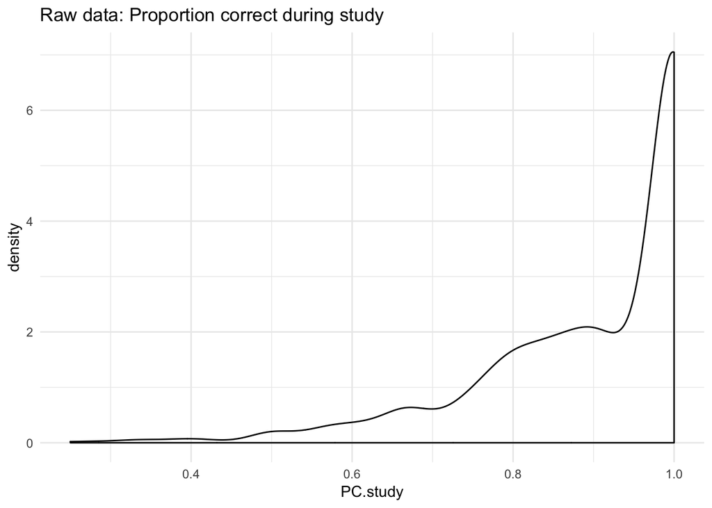

```r
ggplot(exam.item.studied, aes(PC.study)) + geom_density() + labs(title="Raw data: Proportion correct during study")
```

The other predictor that might be problematic is the number of repetitions during study. The reps are highly skewed but a log-transformation seems to work well:

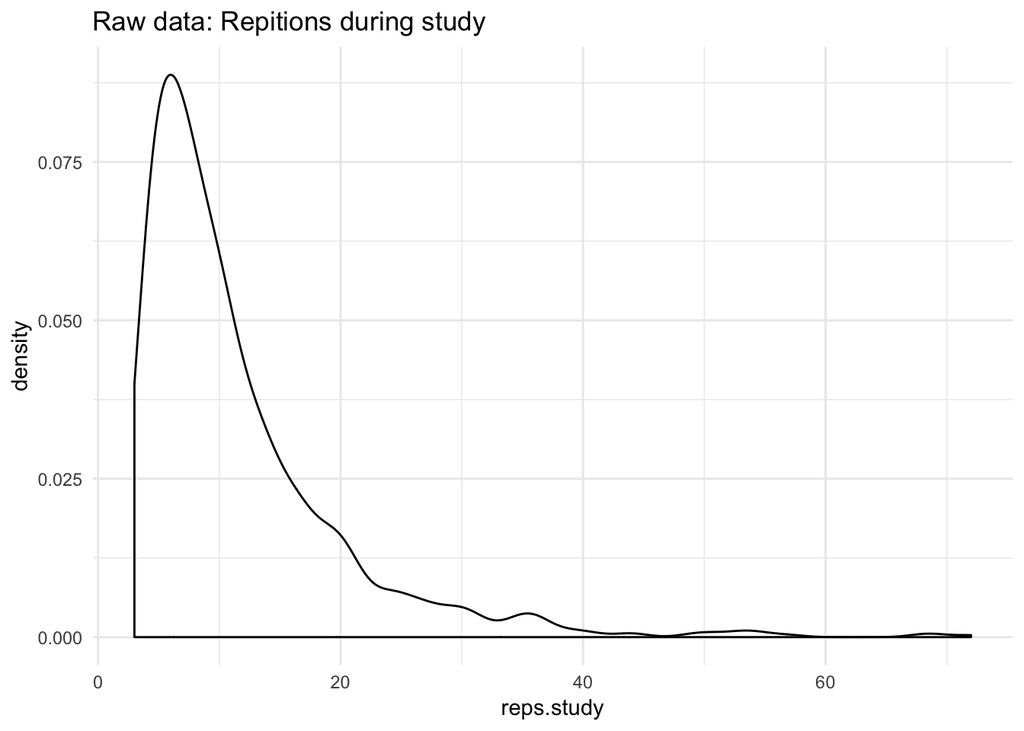

```r
ggplot(exam.item.studied, aes(reps.study)) + geom_density() + labs(title="Raw data: Repitions during study")
```

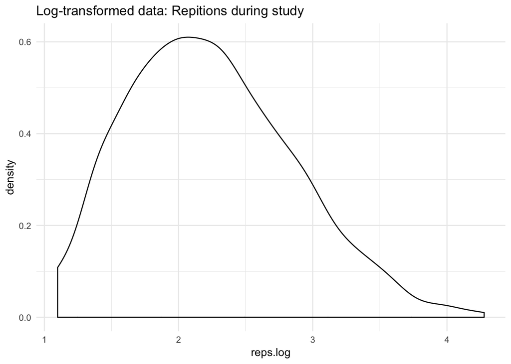

```r
# Logit transformation yields more reasonable results:
exam.item.studied$reps.log <- log(exam.item.studied$reps.study)

ggplot(exam.item.studied, aes(reps.log)) + geom_density() + labs(title="Log-transformed data: Repitions during study")
```

I’ll simply normalize the estimated alpha parameter, they look fine other than the “harmonic bumps” that are an artefact of the step-wise adjustment:

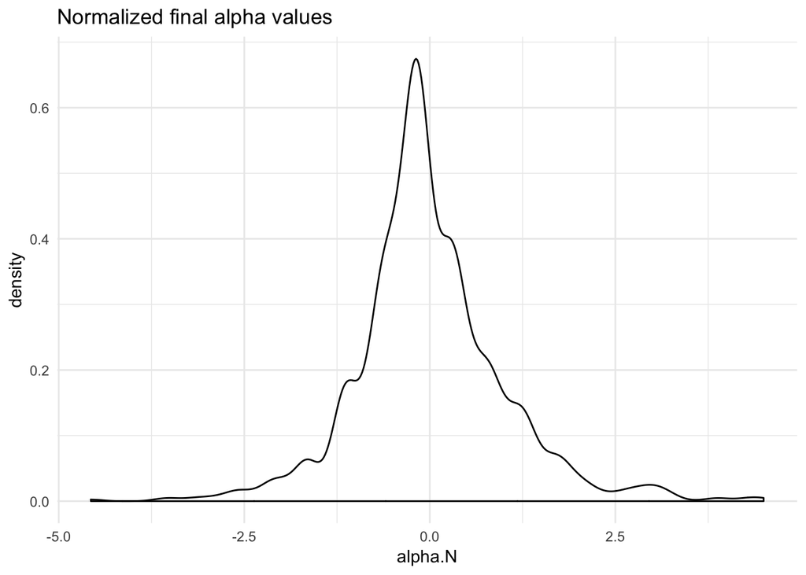

```r
exam.item.studied$alpha.N <- scale(exam.item.studied$final.alpha)

ggplot(exam.item.studied, aes(alpha.N)) + geom_density() + labs(title="Normalized final alpha values")
```

Now we can fit the model:

```r
# Start with full:
summary(m.full <- glmer(correct.exam ~ 1 + alpha.N * reps.log * PC.study + (1|Username) + (1|exam.Q), exam.item.studied, family = "binomial"))
```

```
## Generalized linear mixed model fit by maximum likelihood (Laplace
##   Approximation) [glmerMod]
##  Family: binomial  ( logit )
## Formula:
## correct.exam ~ 1 + alpha.N * reps.log * PC.study + (1 | Username) +
##     (1 | exam.Q)
##    Data: exam.item.studied
##
##      AIC      BIC   logLik deviance df.resid
##    923.2    972.5   -451.6    903.2     1013
##
## Scaled residuals:
##     Min      1Q  Median      3Q     Max
## -5.5017 -0.1997  0.2869  0.4446  5.6181
##
## Random effects:
##  Groups   Name        Variance Std.Dev.
##  Username (Intercept) 0.8863   0.9414
##  exam.Q   (Intercept) 1.2944   1.1377
## Number of obs: 1023, groups:  Username, 130; exam.Q, 10
##
## Fixed effects:
##                             Estimate Std. Error z value Pr(>|z|)
## (Intercept)               -3.6371098  0.0009790 -3714.9   <2e-16 ***
## alpha.N                    2.9738351  0.0009798  3035.1   <2e-16 ***
## reps.log                   1.9630416  0.0009795  2004.0   <2e-16 ***
## PC.study                   4.0477428  0.0009791  4134.1   <2e-16 ***
## alpha.N:reps.log          -0.7191001  0.0009807  -733.3   <2e-16 ***
## alpha.N:PC.study          -4.7782194  0.0009798 -4876.8   <2e-16 ***
## reps.log:PC.study         -1.4261905  0.0009796 -1455.9   <2e-16 ***
## alpha.N:reps.log:PC.study  1.1128380  0.0009807  1134.8   <2e-16 ***
## ---
## Signif. codes:  0 '***' 0.001 '**' 0.01 '*' 0.05 '.' 0.1 ' ' 1
##
## Correlation of Fixed Effects:
##             (Intr) alph.N rps.lg PC.std al.N:. a.N:PC r.:PC.
## alpha.N      0.000
## reps.log     0.000 -0.001
## PC.study     0.000  0.000  0.000
## alph.N:rps.  0.000  0.001 -0.001  0.000
## alph.N:PC.s  0.000  0.001 -0.001  0.000  0.001
## rps.lg:PC.s  0.000 -0.001  0.001  0.000 -0.001 -0.001
## alp.N:.:PC.  0.000  0.001 -0.001  0.000  0.001  0.001 -0.001
## convergence code: 0
## Model failed to converge with max|grad| = 0.0723311 (tol = 0.001, component 1)
## Model is nearly unidentifiable: very large eigenvalue
##  - Rescale variables?
```

```r
# adding control=glmerControl(optimizer="bobyqa",optCtrl=list(maxfun=2e5)) doesn't help convergence either
```

```r
summary(m.noReps <- glmer(correct.exam ~ 1 + alpha.N * PC.study + (1|exam.Q), exam.item.studied, family = "binomial"))
```

```
## Generalized linear mixed model fit by maximum likelihood (Laplace
##   Approximation) [glmerMod]
##  Family: binomial  ( logit )
## Formula: correct.exam ~ 1 + alpha.N * PC.study + (1 | exam.Q)
##    Data: exam.item.studied
##
##      AIC      BIC   logLik deviance df.resid
##    970.3    994.9   -480.1    960.3     1018
##
## Scaled residuals:
##     Min      1Q  Median      3Q     Max
## -5.2659 -0.2584  0.3790  0.5047  3.2094
##
## Random effects:
##  Groups Name        Variance Std.Dev.
##  exam.Q (Intercept) 0.7808   0.8836
## Number of obs: 1023, groups:  exam.Q, 10
##
## Fixed effects:
##                  Estimate Std. Error z value Pr(>|z|)
## (Intercept)       0.01231    0.62992   0.020   0.9844
## alpha.N           1.27905    0.63088   2.027   0.0426 *
## PC.study          1.40405    0.62912   2.232   0.0256 *
## alpha.N:PC.study -2.03100    0.69768  -2.911   0.0036 **
## ---
## Signif. codes:  0 '***' 0.001 '**' 0.01 '*' 0.05 '.' 0.1 ' ' 1
##
## Correlation of Fixed Effects:
##             (Intr) alph.N PC.std
## alpha.N     -0.166
## PC.study    -0.886  0.181
## alph.N:PC.s  0.169 -0.989 -0.188
```

What does the other one look like?

```r
summary(m.noPC <- glmer(correct.exam ~ 1 + alpha.N * reps.log + (1|Username) + (1|exam.Q), exam.item.studied, family = "binomial"))
```

```
## Generalized linear mixed model fit by maximum likelihood (Laplace
##   Approximation) [glmerMod]
##  Family: binomial  ( logit )
## Formula: correct.exam ~ 1 + alpha.N * reps.log + (1 | Username) + (1 |
##     exam.Q)
##    Data: exam.item.studied
##
##      AIC      BIC   logLik deviance df.resid
##    926.3    955.8   -457.1    914.3     1017
##
## Scaled residuals:
##     Min      1Q  Median      3Q     Max
## -5.3349 -0.1953  0.2929  0.4558  5.7410
##
## Random effects:
##  Groups   Name        Variance Std.Dev.
##  Username (Intercept) 0.8726   0.9341
##  exam.Q   (Intercept) 1.2962   1.1385
## Number of obs: 1023, groups:  Username, 130; exam.Q, 10
##
## Fixed effects:
##                  Estimate Std. Error z value Pr(>|z|)
## (Intercept)      -0.02642    0.53795  -0.049  0.96083
## alpha.N          -1.24464    0.42800  -2.908  0.00364 **
## reps.log          0.69481    0.17832   3.897 9.76e-05 ***
## alpha.N:reps.log  0.25506    0.16105   1.584  0.11326
## ---
## Signif. codes:  0 '***' 0.001 '**' 0.01 '*' 0.05 '.' 0.1 ' ' 1
##
## Correlation of Fixed Effects:
##             (Intr) alph.N rps.lg
## alpha.N     -0.193
## reps.log    -0.701  0.226
## alph.N:rps.  0.219 -0.967 -0.278
```

```r
# The interaction is not significant, remove it:
summary(m.noPC.noX <- glmer(correct.exam ~ 1 + alpha.N + reps.log + (1|Username) + (1|exam.Q), exam.item.studied, family = "binomial"))
```

```
## Generalized linear mixed model fit by maximum likelihood (Laplace
##   Approximation) [glmerMod]
##  Family: binomial  ( logit )
## Formula: correct.exam ~ 1 + alpha.N + reps.log + (1 | Username) + (1 |
##     exam.Q)
##    Data: exam.item.studied
##
##      AIC      BIC   logLik deviance df.resid
##    926.6    951.3   -458.3    916.6     1018
##
## Scaled residuals:
##     Min      1Q  Median      3Q     Max
## -5.4639 -0.2042  0.3010  0.4582  5.5349
##
## Random effects:
##  Groups   Name        Variance Std.Dev.
##  Username (Intercept) 0.8581   0.9263
##  exam.Q   (Intercept) 1.2841   1.1332
## Number of obs: 1023, groups:  Username, 130; exam.Q, 10
##
## Fixed effects:
##             Estimate Std. Error z value Pr(>|z|)
## (Intercept)  -0.2242     0.5241  -0.428    0.669
## alpha.N      -0.5948     0.1100  -5.408 6.36e-08 ***
## reps.log      0.7806     0.1724   4.528 5.96e-06 ***
## ---
## Signif. codes:  0 '***' 0.001 '**' 0.01 '*' 0.05 '.' 0.1 ' ' 1
##
## Correlation of Fixed Effects:
##          (Intr) alph.N
## alpha.N   0.088
## reps.log -0.686 -0.191
```

```r
# Just to v
# summary(m.alpha <- glm(correct.exam ~ 1 + alpha.N, exam.item.studied, family = "binomial"))
# summary(m.reps <- glm(correct.exam ~ 1 + reps.log, exam.item.studied, family = "binomial"))
```

The most interesting/sensible model, however, is the one that includes both `alpha.N` *and* `reps.log` but not their interaction. Proportion correct is so high for most people that it is not a very interesting predictor, I think. This is also confirmed by comparing all the models:

```r
anova(m.full, m.noPC, m.noReps, m.noPC.noX)
```

```
## Data: exam.item.studied
## Models:
## m.noReps: correct.exam ~ 1 + alpha.N * PC.study + (1 | exam.Q)
## m.noPC.noX: correct.exam ~ 1 + alpha.N + reps.log + (1 | Username) + (1 |
## m.noPC.noX:     exam.Q)
## m.noPC: correct.exam ~ 1 + alpha.N * reps.log + (1 | Username) + (1 |
## m.noPC:     exam.Q)
## m.full: correct.exam ~ 1 + alpha.N * reps.log * PC.study + (1 | Username) +
## m.full:     (1 | exam.Q)
##            Df    AIC    BIC  logLik deviance  Chisq Chi Df Pr(>Chisq)
## m.noReps    5 970.27 994.92 -480.14   960.27
## m.noPC.noX  5 926.60 951.26 -458.30   916.60 43.668      0    < 2e-16 ***
## m.noPC      6 926.26 955.84 -457.13   914.26  2.346      1    0.12561
## m.full     10 923.18 972.49 -451.59   903.18 11.077      4    0.02571 *
## ---
## Signif. codes:  0 '***' 0.001 '**' 0.01 '*' 0.05 '.' 0.1 ' ' 1
```

Note that the full model has a lower AIC but that the BIC is lowest for the no-prop-correct-and-no-interaction model (i.e., alpha and reps as predictors only). It’s also a much simpler model.

### Visualization

I’ll use the model that includes both the `reps` and `final.alpha` to generate some model predictions that I can plot as a way to visualize the effects captured by the best-fitting model. I’ll take a look at the distribution of the two predictors to identify a range of values that can be predicted using the model:

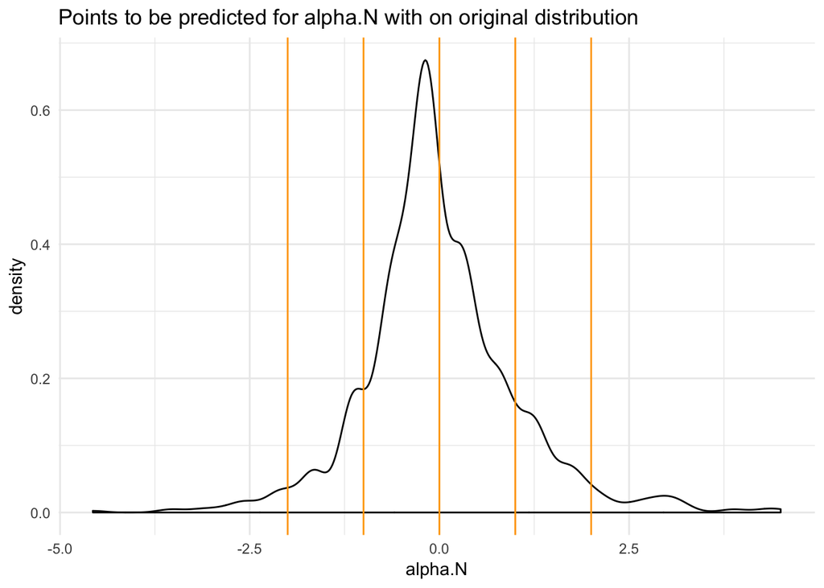

```r
alpha.points <- seq(-2, 2, 1)
ggplot(exam.item.studied, aes(alpha.N)) + geom_density() + geom_vline(xintercept = alpha.points, color="orange") + labs(title="Points to be predicted for alpha.N with on original distribution")
```

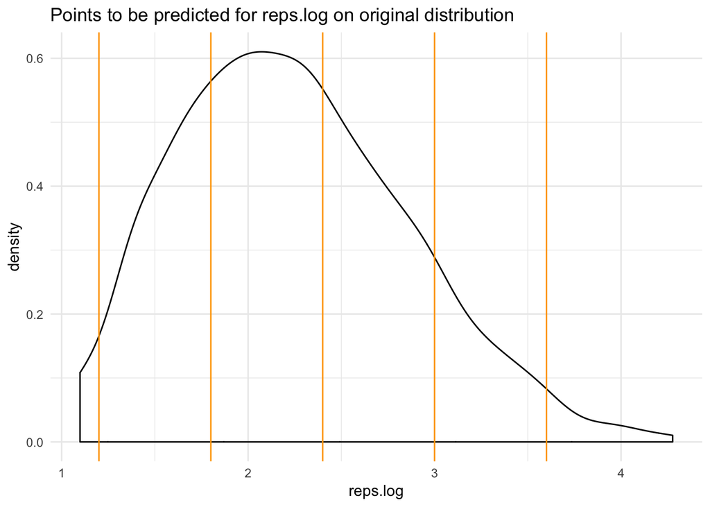

```r
reps.points <- seq(1.2, 3.8, .6)
ggplot(exam.item.studied, aes(reps.log)) + geom_density() + geom_vline(xintercept = reps.points, color="orange") + labs(title="Points to be predicted for reps.log on original distribution")
```

We can use these points to generate a new data set for which to make predictions using the best-fitting model. Note that we’ll not include the random effects in these predictions to simplify the visual presentation and interpretation of the overall patterns:

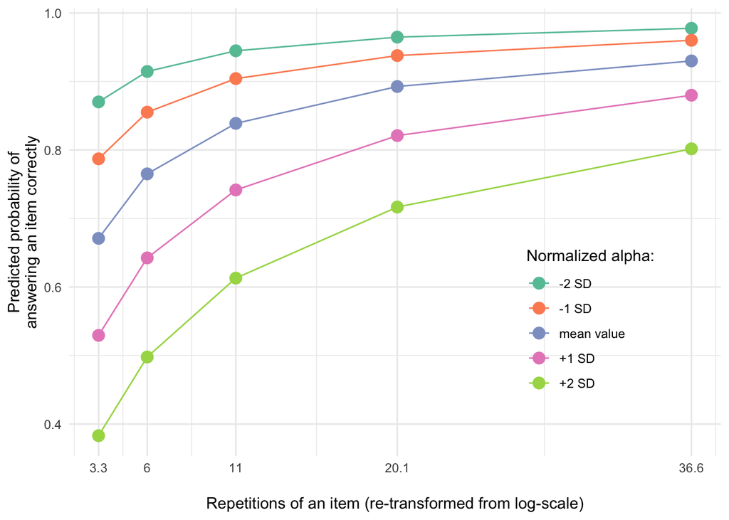

```r
new.data <- data.frame(alpha.N = rep(alpha.points, each = length(reps.points)),
                       reps.log = rep(reps.points, times = length(alpha.points)))

new.data$pred <- predict(m.noPC.noX, newdata=new.data, re.form=NA) # make model predictions w/o random effects

# Convert to original scales:
new.data$pred.prop <- inv.logit(new.data$pred)
new.data$reps <- exp(new.data$reps.log)

ggplot(new.data, aes(reps, pred.prop, group=alpha.N)) +
  # geom_line(aes(color=factor(alpha.N))) +
  # geom_point(aes(color=factor(alpha.N)), size=3) +
  geom_line(aes(color=factor(alpha.N))) +
  geom_point(aes(color=factor(alpha.N)), size=3.5) +
  labs(x="\nRepetitions of an item (re-transformed from log-scale)", y="Predicted probability of\nanswering an item correctly", color="Normalized alpha:") +
  scale_x_continuous(breaks = unique(new.data$reps), labels = round(unique(new.data$reps), 1)) +
  # theme(legend.direction = "horizontal") +
  theme(legend.position = c(.8, .3)) +
  # theme(axis.text.x = element_text(angle = 60, hjust = 1, size=9)) +
  # theme(axis.text.y = element_text(size=9)) +
  scale_color_brewer(palette="Set2", labels=c("-2 SD", "-1 SD", "mean value", "+1 SD", "+2 SD")) +
  NULL
```

```r
# ggsave(file.path(figures.folder, "Pred prop correct f(reps, alpha).pdf"), width = 7, height = 4)
```

This shows nicely that more repetitions lead to a higher probability of answering an item correctly. It also shows that the differences in alpha values between people have a larger effect than the numer of repetitions. The scales are very different, of course, and it’s a bit hard to visualize it in a way that is easier to interpret.

Alternatively, we can predict for all values and then plot a heatmap-type thingy:

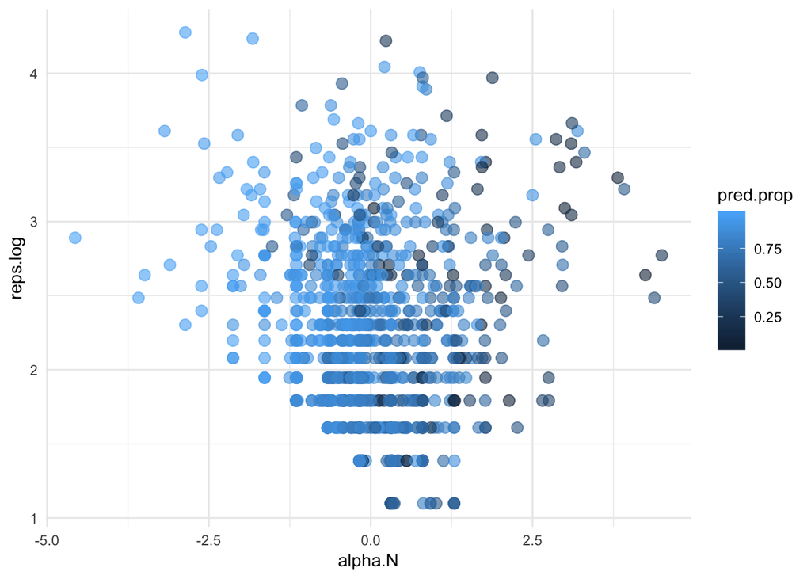

```r
exam.item.studied$pred <- predict(m.noPC.noX)
exam.item.studied$pred.prop <- inv.logit(exam.item.studied$pred)

# library(hexbin) # for stat_hexbin()
ggplot(exam.item.studied, aes(alpha.N, reps.log)) + geom_point(aes(color=pred.prop), size=3, alpha=.6)
```

I think this plot is a bit harder to read. Including the REs makes this a lot messier. I prefer the previous one for the poster.

## Conclusions

Both the number of repetitions and the final alpha parameter associated with each item are signicifant predictors of whether that item will be answered correctly on the exam.